# Scaling Analysis Cori TTbar70

Author: Brain Gravelle (gravelle@cs.uoregon.edu)

All this is using the taucmdr python libraries from paratools http://taucommander.paratools.com/

top  
Loading Data  
Metrics  
Correlations  
Fetch Stalls  
l3_mr

## Imports

This section imports necessary libraies, the metrics.py and utilities.py files and sets up the window.

```python
# A couple of scripts to set the environent and import data from a .tau set of results
from utilities import *
from metrics import *
# Plotting, notebook settings:
%matplotlib inline
#plt.rcParams.update({'font.size': 16})
import numbers
from IPython.core.display import display, HTML
display(HTML("<style>.container { width:100% !important; }</style>"))
pd.set_option('display.float_format', lambda x: '%.2e' % x)
pd.set_option('display.max_columns',100)
pd.set_option('max_colwidth', 70)

from IPython.core.interactiveshell import InteractiveShell
InteractiveShell.ast_node_interactivity = "all"

import copy
```

## Getting Data

TAU Commander uses TAU to run the application and measure it using runtime sampling techniques (similar to Intel VTune). Many customization options are available. For example, we may consider each function regardless of calling context, or we may decide to enable callpath profiling to see each context separately.

From the talapas_scaling application the following experiments are available. These use Talapas (with 28 thread Broadwell processors) and the build-ce (realistic) option for mkFit. The first six experiments use the --num-thr option to set the thread count which is intended to perform threading within the events. the last two add the --num-ev-thr option to set the event threads, so that all threads are used to process events in parallel and each event is processed by a single thread.

- manual_scaling_Large_talapas
- manual_scaling_Large_talapas_fullnode
- manual_scaling_TTbar70_talapas
- manual_scaling_TTbar70_talapas_fullnode
- manual_scaling_TTbar35_talapas
- manual_scaling_TTbar35_talapas_fullnode
- ev_thr_scaling_Large_talapas
- ev_thr_scaling_Large_talapas_fullnode

Additionally available in the cori_scaling application are the following. These were run on NERSC's Cori on the KNL with the default memory settings (quad - 1 NUMA domain, cache - MCDRAM as direct mapped cache). See http://www.nersc.gov/users/computational-systems/cori/running-jobs/advanced-running-jobs-options/ for more info on the KNL modes. Similar to the talapas scaling they use the build-ce option and threading within each event.

- manual_scaling_TTbar35
- manual_scaling_TTbar70
- manual_scaling_Large
- mixed_thr_scaling_Large - this is bad

### Importing Scaling Data - Cori TTbar70 is current

Here we import the data. In this case we are using Cori data from the experiments with the threads working within each event using the TTbar70 file. Note that this box will take an hour or more to run; please go enjoy a coffee while you wait.

```python
# application = "talapas_scaling"
# experiment  = "manual_scaling_TTbar70_talapas"
# experiment  = "manual_scaling_Large_talapas"
# experiment = "ev_thr_scaling_Large_talapas"

application = "cori_scaling"
# experiment  = "manual_scaling_TTbar35"
experiment  = "manual_scaling_TTbar70"
# experiment  = "manual_scaling_Large"
# experiment  = "mixed_thr_scaling_Large"

path = ".tau/" + application + "/" + experiment + "/"
# note that this function takes a long time to run, so only rerun if you must

metric_data = get_pandas_scaling(path, callpaths=True)

if application == "talapas_scaling":
    metric_data = remove_erroneous_threads(metric_data,  [1, 8, 16, 32, 48, 56])
elif application == "cori_scaling":
    print(metric_data.keys())
    metric_data = remove_erroneous_threads(metric_data,  [1, 4, 8, 16, 32, 48, 64, 80, 96, 112, 128, 144, 160, 176, 192, 208, 224, 240, 256])
```

```
Parsing ERROR:
dir = .tau/cori_scaling/manual_scaling_TTbar70/0_208_61//MULTI__PAPI_LST_INS
Found: 1101 trials with 10 errors


[256, 64, 1, 8, 128, 16, 18, 32, 112, 34, 176, 48, 192, 160, 96, 80, 82, 224, 144, 226, 208, 146, 272, 240]
```

## Adding metrics

metrics are available in metrics.py. At this time the following can be added:

- add_IPC(metrics) - Instructions per Cycle
- add_CPI(metrics) - Cycles per instruction
- add_VIPC(metrics) - vector instructions per cycle
- add_VIPI(metrics) - vector instructions per instruction (i.e. fraction of total)
- add_L1_missrate(metrics) - miss rate for L1 cache

for scaling data please use the add_metric_to_scaling_data(data, metric_func) function to add a metric

```python
add_metric_to_scaling_data(metric_data, add_CPI)
add_metric_to_scaling_data(metric_data, add_IPC)
add_metric_to_scaling_data(metric_data, add_L1_missrate)
add_metric_to_scaling_data(metric_data, add_L2_missrate)
add_metric_to_scaling_data(metric_data, add_VIPI)
if application == 'cori_scaling': llc = True
else: llc = False
add_metric_to_scaling_data(metric_data, add_L3_missrate, llc)
print_available_metrics(metric_data, scaling=True)

add_metric_to_scaling_data(metric_data, add_DERIVED_BRANCH_MR)
add_metric_to_scaling_data(metric_data, add_DERIVED_RATIO_FETCH_STL_TOT_CYC)

# To test
# metric_data[1]['DERIVED_IPC'].sort_values(by='Inclusive',ascending=False).head(10)
```

```
DERIVED_VIPI
PAPI_NATIVE_UOPS_RETIRED:SCALAR_SIMD
PAPI_L2_TCA
PAPI_NATIVE_LLC_MISSES
PAPI_TLB_DM
PAPI_L2_TCM
PAPI_NATIVE_FETCH_STALL
PAPI_NATIVE_UOPS_RETIRED:PACKED_SIMD
DERIVED_CPI
PAPI_L1_TCM
PAPI_BR_MSP
PAPI_RES_STL
PAPI_TOT_INS
PAPI_BR_CN
DERIVED_L1_MISSRATE
DERIVED_L3_MISSRATE
PAPI_BR_UCN
PAPI_NATIVE_LLC_REFERENCES
PAPI_BR_INS
DERIVED_L2_MISSRATE
DERIVED_IPC
PAPI_LST_INS
PAPI_NATIVE_RS_FULL_STALL
PAPI_TOT_CYC
```

#### Combining metrics

```python
THREAD_COUNT = 32

alldata = combine_metrics(metric_data[THREAD_COUNT],inc_exc='Exclusive')
```

## Scaling Results

In this section we carefully walk through an analysis of the application to find areas of interest.

We begin by looking at correlations of data to determine metrics of interest and then move on to ploting those metric. In this analysis we primarily use PAPI_TOT_CYC as a proxy for the time it takes a function to complete.

## Correlations

```python
cm = sns.light_palette("yellow", as_cmap=True)

def get_corr(alldata, method='pearson', metrics=['PAPI_TOT_CYC', 'PAPI_TOT_INS']):
    correlations = alldata.corr(method).fillna(0)[metrics]    # Other methods: 'kendall', 'spearman'
    return correlations.style.format("{:.2%}").background_gradient(cmap=cm)

pcorr = get_corr(alldata)
kcorr = get_corr(alldata, method='kendall')
scorr = get_corr(alldata, method='spearman')
```

```python
metric_li = ['PAPI_TOT_CYC','PAPI_TOT_INS']

corrs = [alldata.corr('pearson').fillna(0)[metric_li], alldata.corr('kendall').fillna(0)[metric_li], alldata.corr('spearman').fillna(0)[metric_li]]

corr_data = corrs[0][['PAPI_TOT_CYC']].copy()
corr_data['p_PAPI_TOT_CYC'] = corr_data['PAPI_TOT_CYC']
corr_data['p_PAPI_TOT_INS'] = corrs[0]['PAPI_TOT_INS']

corr_data['k_PAPI_TOT_CYC'] = corrs[1]['PAPI_TOT_CYC']
corr_data['k_PAPI_TOT_INS'] = corrs[1]['PAPI_TOT_INS']

corr_data['s_PAPI_TOT_CYC'] = corrs[2]['PAPI_TOT_CYC']
corr_data['s_PAPI_TOT_INS'] = corrs[2]['PAPI_TOT_INS']

corr_data.drop(['PAPI_TOT_CYC'],axis=1,inplace=True)

corr_data.style.format("{:.2%}").background_gradient(cmap=cm)
```

|  | p_PAPI_TOT_CYC | p_PAPI_TOT_INS | k_PAPI_TOT_CYC | k_PAPI_TOT_INS | s_PAPI_TOT_CYC | s_PAPI_TOT_INS |
| --- | --- | --- | --- | --- | --- | --- |
| PAPI_TOT_CYC | 100.00% | 60.17% | 100.00% | 50.20% | 100.00% | 62.88% |
| DERIVED_VIPI | 0.42% | -11.67% | 18.42% | 3.32% | 28.06% | 5.99% |
| PAPI_NATIVE_UOPS_RETIRED:SCALAR_SIMD | 20.97% | 74.32% | 41.58% | 67.86% | 52.84% | 83.14% |
| PAPI_L2_TCA | 75.23% | 92.60% | 49.19% | 73.51% | 62.47% | 88.83% |
| PAPI_NATIVE_LLC_MISSES | 78.18% | 85.12% | 46.69% | 73.14% | 59.92% | 88.35% |
| PAPI_TLB_DM | 54.52% | 83.70% | 43.82% | 66.73% | 56.99% | 83.30% |
| PAPI_L2_TCM | 75.58% | 85.70% | 51.83% | 78.03% | 64.51% | 91.77% |
| PAPI_NATIVE_UOPS_RETIRED:PACKED_SIMD | 78.75% | 74.12% | 43.89% | 63.00% | 58.31% | 79.25% |
| PAPI_NATIVE_FETCH_STALL | 86.78% | 72.38% | 53.47% | 69.59% | 68.44% | 85.91% |
| PAPI_L1_TCM | 74.25% | 91.75% | 51.80% | 78.28% | 64.84% | 92.15% |
| PAPI_BR_MSP | 43.39% | 95.19% | 50.52% | 77.98% | 61.97% | 92.17% |
| PAPI_RES_STL | 22.53% | 52.36% | 34.40% | 62.14% | 44.06% | 80.17% |
| PAPI_TOT_INS | 60.17% | 100.00% | 50.20% | 100.00% | 62.88% | 100.00% |
| DERIVED_IPC | -9.70% | 37.01% | -29.41% | 12.74% | -41.86% | 18.87% |
| PAPI_BR_CN | 28.86% | 87.76% | 42.81% | 76.62% | 53.56% | 91.28% |
| DERIVED_RATIO_FETCH_STL_TOT_CYC | 1.26% | -7.10% | 11.37% | -0.44% | 17.43% | -0.62% |
| DERIVED_L1_MISSRATE | 2.31% | 0.13% | 5.69% | 3.00% | 8.17% | 3.76% |
| DERIVED_L3_MISSRATE | 1.07% | 3.08% | 0.74% | 8.48% | 0.41% | 11.97% |
| PAPI_BR_UCN | 32.64% | 76.76% | 45.15% | 77.36% | 57.19% | 91.99% |
| PAPI_NATIVE_LLC_REFERENCES | 75.09% | 92.02% | 48.12% | 73.28% | 61.46% | 88.50% |
| PAPI_BR_INS | 30.00% | 89.71% | 43.63% | 76.61% | 54.95% | 91.29% |
| DERIVED_L2_MISSRATE | -2.53% | -1.91% | -0.04% | 8.62% | -1.01% | 12.32% |
| DERIVED_BRANCH_MR | 1.26% | -7.10% | 11.37% | -0.44% | 17.43% | -0.62% |
| DERIVED_CPI | 13.53% | -15.09% | 41.74% | -11.39% | 56.95% | -16.85% |
| PAPI_LST_INS | 40.59% | 80.37% | 49.36% | 79.06% | 61.67% | 92.58% |
| PAPI_NATIVE_RS_FULL_STALL | 23.90% | 61.20% | 32.34% | 61.87% | 41.58% | 79.77% |

### Correlation Take Aways

From the correlation results it appears that one of the largest contributors to cycles is the fetch stalls that occur when data from cache or memory is not available when it is needed. Because of this finding we will explore the number of such stalls in different threads and functions.

## Fetch Stalls

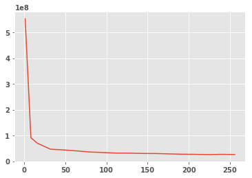

```python
thread_list, FETCH_STALL_data = scaling_plot(metric_data, plot=False, metric='PAPI_NATIVE_FETCH_STALL')

plt = matplotlib.pyplot.plot(thread_list, FETCH_STALL_data)
```

```
1
```

```
<BarContainer object of 1 artists>
```

```
(0.0, 2000000000.0)
```

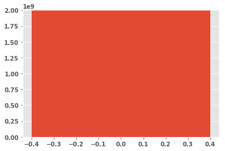

```
8
```

```
<BarContainer object of 8 artists>
```

```
(0.0, 2000000000.0)
```

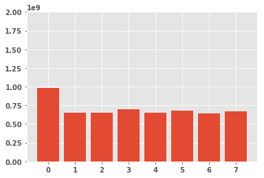

```
16
```

```
<BarContainer object of 16 artists>
```

```
(0.0, 2000000000.0)
```

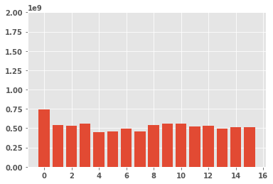

```
32
```

```
<BarContainer object of 32 artists>
```

```
(0.0, 2000000000.0)
```

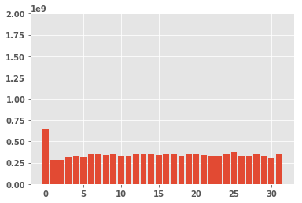

```
48
```

```
<BarContainer object of 48 artists>
```

```
(0.0, 2000000000.0)
```

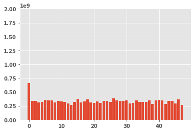

```
64
```

```
<BarContainer object of 64 artists>
```

```
(0.0, 2000000000.0)
```

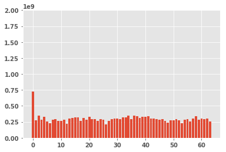

```
80
```

```
<BarContainer object of 80 artists>
```

```
(0.0, 2000000000.0)
```

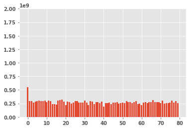

```
96
```

```
<BarContainer object of 96 artists>
```

```
(0.0, 2000000000.0)
```

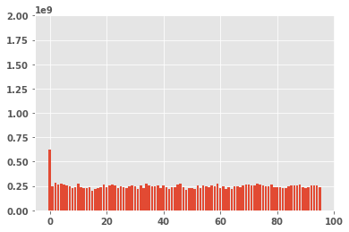

```
112
```

```
<BarContainer object of 112 artists>
```

```
(0.0, 2000000000.0)
```

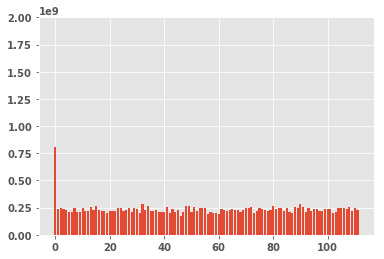

```
128
```

```
<BarContainer object of 128 artists>
```

```
(0.0, 2000000000.0)
```

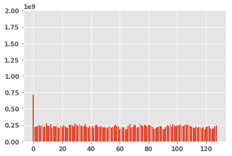

```
144
```

```
<BarContainer object of 144 artists>
```

```
(0.0, 2000000000.0)
```

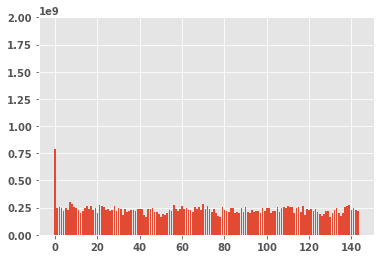

```
160
```

```
<BarContainer object of 160 artists>
```

```
(0.0, 2000000000.0)
```

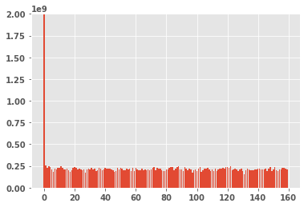

```
176
```

```
<BarContainer object of 176 artists>
```

```
(0.0, 2000000000.0)
```

[6 more figures not shown]

```python
thread_FETCH_STL_data = get_thread_level_metric_scaling(metric_data, metric='PAPI_NATIVE_FETCH_STALL')

for kt in thread_list:
    print kt
    data = list(thread_FETCH_STL_data[kt])
    matplotlib.pyplot.bar(range(len(data)), data)
    matplotlib.pyplot.ylim(ymax=2e9)
    matplotlib.pyplot.show()
```

```python
FS_data = select_metric_from_scaling(metric_data, 'PAPI_NATIVE_FETCH_STALL')
FS_dict = {}
for n_thr in thread_list:
    FS_dict[n_thr] = filter_libs_out(FS_data[n_thr]).sort_values(by='Exclusive',ascending=False)[["Exclusive"]]
print thread_list
```

```
[1, 8, 16, 32, 48, 64, 80, 96, 112, 128, 144, 160, 176, 192, 208, 224, 240, 256]
```

```python
THREAD_COUNT = 1
func = 'NULL'
# func = 'FindCandidatesCloneEngine' # NULL for nothing
# func = 'SelectHitIndices' # NULL for nothing
get_func_level_metric(FS_dict[THREAD_COUNT], func=func, avg=True).head(20)
```

| region | Exclusive |
| --- | --- |
| [SUMMARY] .TAU application => [CONTEXT] .TAU application => [SAMPLE] MkFinder::SelectHitIndices(LayerOfHits const&, int) | 1.68e+08 |
| [SUMMARY] MkFinder::SelectHitIndices(LayerOfHits const&, int) | 1.68e+08 |
| [SUMMARY] __svml_sincosf8_l9 | 8.62e+07 |
| [SUMMARY] .TAU application => [CONTEXT] .TAU application => [SAMPLE] __svml_sincosf8_l9 | 8.62e+07 |
| [SUMMARY] .TAU application => [CONTEXT] .TAU application => [SAMPLE] MkFinder::FindCandidatesCloneEngine(LayerOfHits const&, CandCloner&, int, int, FindingFoos const&) | 7.28e+07 |
| [SUMMARY] MkFinder::FindCandidatesCloneEngine(LayerOfHits const&, CandCloner&, int, int, FindingFoos const&) | 7.28e+07 |
| [SUMMARY] .TAU application => [CONTEXT] .TAU application => [SAMPLE] Matriplex::MatriplexSym<float, 6, 8>::CopyIn(int, float const*) | 5.10e+07 |
| [SUMMARY] Matriplex::MatriplexSym<float, 6, 8>::CopyIn(int, float const*) | 5.10e+07 |
| [SUMMARY] .TAU application => [CONTEXT] .TAU application => [SAMPLE] helixAtZ(Matriplex::Matriplex<float, 6, 1, 8> const&, Matriplex::Matriplex<int, 1, 1, 8> const&, Matriplex::Matriplex<float, 6, 1, … | 4.09e+07 |
| [SUMMARY] helixAtZ(Matriplex::Matriplex<float, 6, 1, 8> const&, Matriplex::Matriplex<int, 1, 1, 8> const&, Matriplex::Matriplex<float, 6, 1, 8>&, Matriplex::Matriplex<float, 1, 1, 8> const&, Matriplex… | 4.09e+07 |
| [SUMMARY] void _INTERNALff9a2cb1::helixAtRFromIterativeCCS_impl<Matriplex::Matriplex<float, 6, 1, 8>, Matriplex::Matriplex<int, 1, 1, 8>, Matriplex::Matriplex<float, 6, 1, 8>, Matriplex::Matriplex<flo… | 3.25e+07 |
| [SUMMARY] .TAU application => [CONTEXT] .TAU application => [SAMPLE] void _INTERNALff9a2cb1::helixAtRFromIterativeCCS_impl<Matriplex::Matriplex<float, 6, 1, 8>, Matriplex::Matriplex<int, 1, 1, 8>, Mat… | 3.25e+07 |
| [SUMMARY] .TAU application => [CONTEXT] .TAU application => [SAMPLE] Matriplex::MatriplexSym<float, 6, 8>::CopyOut(int, float*) const | 2.56e+07 |
| [SUMMARY] Matriplex::MatriplexSym<float, 6, 8>::CopyOut(int, float*) const | 2.56e+07 |
| [SUMMARY] FMA(__m256 const&, __m256 const&, __m256 const&) | 2.48e+07 |
| [SUMMARY] .TAU application => [CONTEXT] .TAU application => [SAMPLE] FMA(__m256 const&, __m256 const&, __m256 const&) | 2.48e+07 |
| [SUMMARY] __intel_avx_rep_memset | 2.23e+07 |
| [SUMMARY] .TAU application => [CONTEXT] .TAU application => [SAMPLE] __intel_avx_rep_memset | 2.23e+07 |
| [SUMMARY] .TAU application => [CONTEXT] .TAU application => [SAMPLE] Matriplex::MatriplexSym<float, 3, 8>::SlurpIn(char const*, int*, int) | 2.21e+07 |
| [SUMMARY] Matriplex::MatriplexSym<float, 3, 8>::SlurpIn(char const*, int*, int) | 2.21e+07 |

## Stalls per Cycle

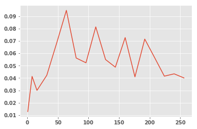

```python
thread_list, FETCH_STALL_data = scaling_plot(metric_data, plot=False, metric='PAPI_NATIVE_FETCH_STALL')
thread_list, TOT_CYC_data = scaling_plot(metric_data, plot=False, metric='PAPI_TOT_CYC')

FS_P_CYC_list = [FETCH_STALL_data[i] / TOT_CYC_data[i] for i in range(len(thread_list))]

plt = matplotlib.pyplot.plot(thread_list, FS_P_CYC_list)
```

```
1
```

```
<BarContainer object of 1 artists>
```

```
(0.0, 0.2)
```

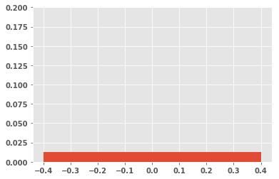

```
8
```

```
<BarContainer object of 8 artists>
```

```
(0.0, 0.2)
```

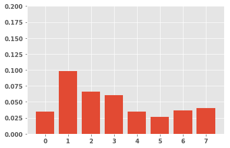

```
16
```

```
<BarContainer object of 16 artists>
```

```
(0.0, 0.2)
```

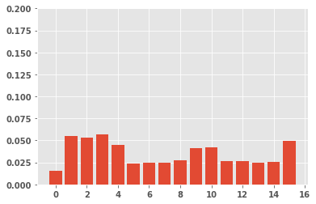

```
32
```

```
<BarContainer object of 32 artists>
```

```
(0.0, 0.2)
```

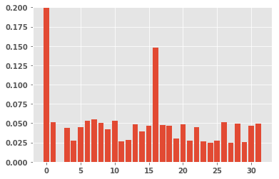

```
48
```

```
<BarContainer object of 48 artists>
```

```
(0.0, 0.2)
```

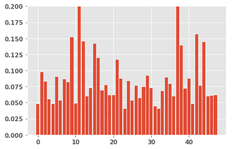

```
64
```

```
<BarContainer object of 64 artists>
```

```
(0.0, 0.2)
```

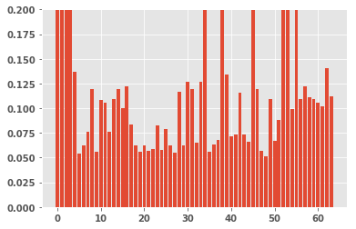

```
80
```

```
<BarContainer object of 80 artists>
```

```
(0.0, 0.2)
```

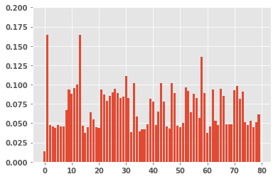

```
96
```

```
<BarContainer object of 96 artists>
```

```
(0.0, 0.2)
```

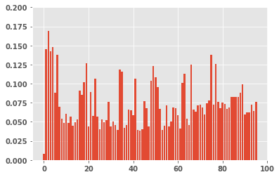

```
112
```

```
<BarContainer object of 112 artists>
```

```
(0.0, 0.2)
```

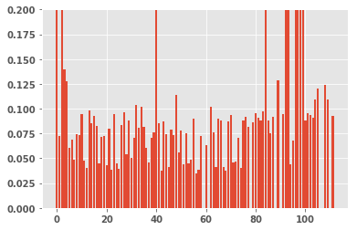

```
128
```

```
<BarContainer object of 128 artists>
```

```
(0.0, 0.2)
```

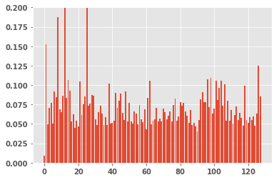

```
144
```

```
<BarContainer object of 144 artists>
```

```
(0.0, 0.2)
```

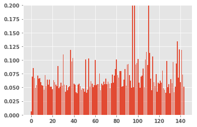

```
160
```

```
<BarContainer object of 160 artists>
```

```
(0.0, 0.2)
```

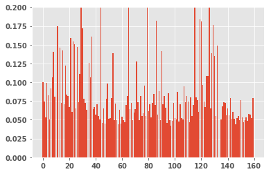

```
176
```

```
<BarContainer object of 176 artists>
```

```
(0.0, 0.2)
```

[6 more figures not shown]

```python
thread_TOT_CYC_data = get_thread_level_metric_scaling(metric_data, metric='PAPI_TOT_CYC')
thread_FETCH_STL_data = get_thread_level_metric_scaling(metric_data, metric='PAPI_NATIVE_FETCH_STALL')

FS_P_CYC_data = {}
for kt in thread_list:
#     print(thread_L1M_data[kt])
#     print(thread_L1A_data[kt])
    FS_P_CYC_data[kt] = thread_FETCH_STL_data[kt] / thread_TOT_CYC_data[kt]

for kt in thread_list:
    print kt
    data = list(FS_P_CYC_data[kt])
    matplotlib.pyplot.bar(range(len(data)), data)
    matplotlib.pyplot.ylim(ymax=0.2)
    matplotlib.pyplot.show()
```

```python
FSTC_data = select_metric_from_scaling(metric_data, 'DERIVED_RATIO_FETCH_STL_TOT_CYC')
FSTC_dict = {}


def filter_libs_out_2(dfs):
    dfs_filtered = dfs.groupby(level='region').filter(lambda x: ('.TAU application ' not in x.name) and ('tbb' not in x.name) and ('syscall' not in x.name)  and ('std::' not in x.name))
    return dfs_filtered

for n_thr in thread_list:
    FSTC_dict[n_thr] = filter_libs_out_2(FSTC_data[n_thr]).sort_values(by='Exclusive',ascending=False)[["Exclusive"]]
#     FSTC_dict[n_thr] = FSTC_data[n_thr].sort_values(by='Exclusive',ascending=False)[["Exclusive"]]
print thread_list
```

```
[1, 8, 16, 32, 48, 64, 80, 96, 112, 128, 144, 160, 176, 192, 208, 224, 240, 256]
```

```python
THREAD_COUNT = 32
func = 'NULL'
# func = 'FindCandidatesCloneEngine' # NULL for nothing
# func = 'SelectHitIndices' # NULL for nothing
get_func_level_metric(FSTC_dict[THREAD_COUNT], func=func, avg=True).head(10)
```

| region | Exclusive |
| --- | --- |
| [SUMMARY] Matriplex::MatriplexSym<float, 6, 8>::operator=(Matriplex::MatriplexSym<float, 6, 8> const&) | 2.30e-01 |
| [SUMMARY] _ZNSt4pairIKiiEC1IIOiEILm0EEIEIEEERSt5tupleIIDpT_EERS4_IIDpT1_EESt12_Index_tupleIIXT0_EEESD_IIXT2_EEE | 2.23e-01 |
| [SUMMARY] _ZN9__gnu_cxx13new_allocatorIN8MkFinder11IdxChi2ListEE9constructIS2_IRKS2_EEEvPT_DpOT0_ | 1.96e-01 |
| [SUMMARY] Matriplex::Matriplex<int, 16, 1, 8>::At(int, int, int) | 1.94e-01 |
| [SUMMARY] (anonymous namespace)::MultHelixProp(Matriplex::Matriplex<float, 6, 6, 8> const&, Matriplex::MatriplexSym<float, 6, 8> const&, Matriplex::Matriplex<float, 6, 6, 8>&) | 1.75e-01 |
| [SUMMARY] Matriplex::Matriplex<float, 6, 1, 8>::CopyOut(int, float*) const | 1.52e-01 |
| [SUMMARY] (anonymous namespace)::sortCandListByHitsChi2(MkFinder::IdxChi2List const&, MkFinder::IdxChi2List const&) | 1.42e-01 |
| [SUMMARY] computeChi2EndcapMPlex(Matriplex::MatriplexSym<float, 6, 8> const&, Matriplex::Matriplex<float, 6, 1, 8> const&, Matriplex::Matriplex<int, 1, 1, 8> const&, Matriplex::MatriplexSym<float, 3, … | 1.32e-01 |
| [SUMMARY] applyMaterialEffects(Matriplex::Matriplex<float, 1, 1, 8> const&, Matriplex::Matriplex<float, 1, 1, 8> const&, Matriplex::MatriplexSym<float, 6, 8>&, Matriplex::Matriplex<float, 6, 1, 8>&, i… | 1.30e-01 |
| [SUMMARY] _ZN9__gnu_cxx13new_allocatorINSt8__detail10_Hash_nodeISt4pairIKiiELb0EEEE9constructIS6_IRKSt21piecewise_construct_tSt5tupleIIOiEESC_IIEEEEEvPT_DpOT0_ | 1.27e-01 |